# Analysis of SCPCP000001

Stephanie J. Spielman

2025-02-06

This goal of this notebook is to explore `SCPCP000001` based on its additive random effects model `bulk ~ pseudobulk + (1|sample_id)`.

## Setup

```r
renv::load()

library(ggplot2)
theme_set(theme_bw())
```

### Paths

```r
analysis_dir <- here::here("analysis", "pseudobulk-bulk-prediction")
model_file <- file.path(analysis_dir, "results", "models", "SCPCP000001_bulk-pseudobulk-model.rds")
```

Define files to read in:

```r
model_data <- readr::read_rds(model_file)

model_df <- model_data$data |>
  dplyr::mutate(residuals = unname(resid(model_data$model)))
sigma <- unname(model_data$model@devcomp$cmp["sigmaML"])

n_samples <- length(unique(model_data$data$sample_id))
```

## GSEA with Hallmark gene set

We’ll explore the potential utility of using GSEA on residuals to identify biological patterns of outlier genes. For this, we’ll use the Hallmark gene set from `MSigDB`.

```r
hallmark_df <- msigdbr::msigdbr(species = "Homo sapiens", category = "H") # 50 gene sets
```

We’ll run GSEA for each sample.

```r
hallmark_gsea <- unique(model_df$sample_id) |>
  purrr::set_names(unique(model_df$sample_id)) |>
  purrr::map(
    \(id) {
      # arrange *decreasing*
      ranked_residuals <- model_df |>
        dplyr::filter(sample_id == id) |>
        dplyr::arrange(-residuals) |>
        dplyr::pull(residuals, name = ensembl_id)

      gsea_results <- clusterProfiler::GSEA(
        geneList = ranked_residuals,
        TERM2GENE = dplyr::select(hallmark_df, gs_name, ensembl_gene)
      )
  })
```

Since we ran this for each sample, we’ll be a little more stringent with P-values and look for significant gene sets where the adjusted P-value is less than `0.01 / <number of samples>`.

```r
threshold <- 0.01/length(unique(model_df$sample_id))

# Find significant gene sets, both positive and negative
sig_lists <- hallmark_gsea |>
  purrr::map(
    \(gsea_result) {

      sig_df <- gsea_result@result |>
        dplyr::filter(p.adjust <= threshold)

      list(
        neg = sig_df$ID[sig_df$NES < 0],
        pos = sig_df$ID[sig_df$NES > 0]
      )
    }
  )

# Pluck out negative and positive to look at them separately
neg_sig_lists <- sig_lists |> purrr::map(purrr::pluck, "neg")
pos_sig_lists <- sig_lists |> purrr::map(purrr::pluck, "pos")
```

How many gene signatures were identified in either direction per sample?

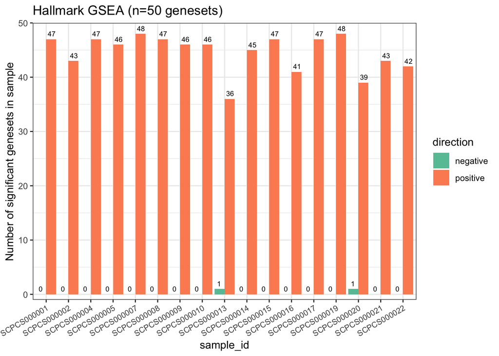

```r
# Count the number of positive and negatives per sample
gs_count_df <- purrr::map2(
  neg_sig_lists,
  pos_sig_lists,
  \(neg_gs, pos_gs) {

    data.frame(
      negative = length(neg_gs),
      positive = length(pos_gs)
    )

  }) |>
  purrr::set_names(names(neg_sig_lists)) |>
  purrr::list_rbind(names_to = "sample_id") |>
  tidyr::pivot_longer(
    !sample_id,
    names_to = "direction",
    values_to = "n_gene_sets"
  )


# Barplot of counts per sample
ggplot(gs_count_df) +
  aes(x = sample_id, y = n_gene_sets, fill = direction) +
  geom_col(position = position_dodge()) +
  geom_text(
    aes(label = n_gene_sets, y = n_gene_sets + 1),
    position = position_dodge(width = 1),
    size = 2.5
  ) +
  scale_fill_brewer(palette = "Set2") +
  labs(
    title = "Hallmark GSEA (n=50 genesets)",
    y = "Number of significant genesets in sample"
  ) +
  scale_y_continuous(expand = c(0,1)) +
  theme(axis.text.x = element_text(angle = 30, hjust = 1, size = 8))
```

It looks like, in *all samples*, the *vast* majority of hallmark pathways are coming back significantly positively “enriched.” Only two samples show evidence of negative “enrichment,” and only one gene set each. This seems like too many hallmark pathways in the positives, but we’ll push forward a bit still…

While there’s not much overlap to see in the negative direction, what about the positive? Which pathways are enriched among all samples?

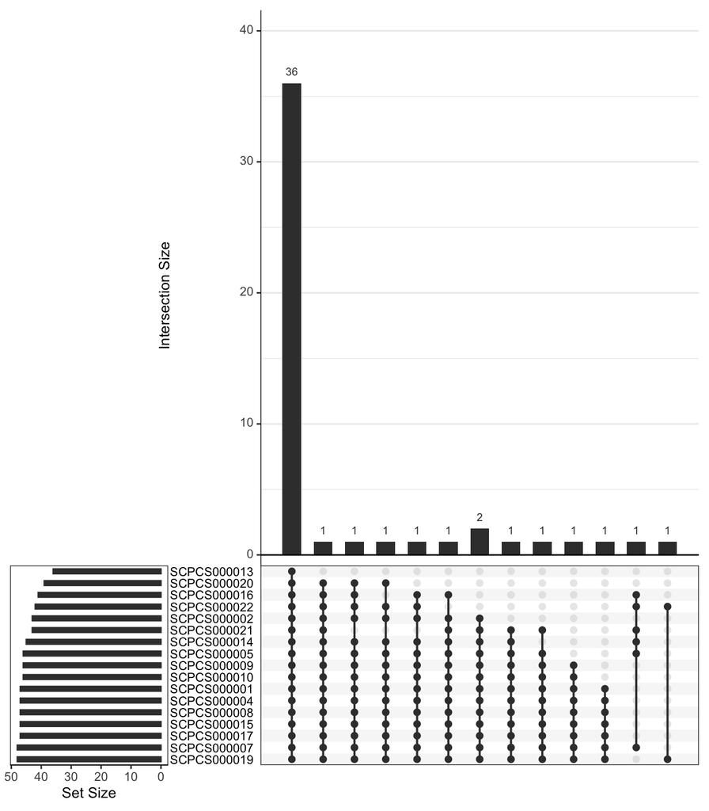

```r
 UpSetR::upset(
   UpSetR::fromList(pos_sig_lists),
   order.by = "degree", # order columns by number of samples
   text.scale = 1.25,
   nsets = 100 # make sure all sets are plotted, not only top 5
  )
```

Those pathways are:

```r
pos_sig_lists |>
  purrr::reduce(intersect)
```

```
 [1] "HALLMARK_EPITHELIAL_MESENCHYMAL_TRANSITION"
 [2] "HALLMARK_MYOGENESIS"
 [3] "HALLMARK_HYPOXIA"
 [4] "HALLMARK_MTORC1_SIGNALING"
 [5] "HALLMARK_APICAL_JUNCTION"
 [6] "HALLMARK_ADIPOGENESIS"
 [7] "HALLMARK_ESTROGEN_RESPONSE_EARLY"
 [8] "HALLMARK_MYC_TARGETS_V1"
 [9] "HALLMARK_UNFOLDED_PROTEIN_RESPONSE"
[10] "HALLMARK_OXIDATIVE_PHOSPHORYLATION"
[11] "HALLMARK_UV_RESPONSE_UP"
[12] "HALLMARK_P53_PATHWAY"
[13] "HALLMARK_GLYCOLYSIS"
[14] "HALLMARK_ESTROGEN_RESPONSE_LATE"
[15] "HALLMARK_APOPTOSIS"
```

[output cut: 21 more lines]

[output not shown]

Let’s look at one set of GSEA plots for one pathway, across all samples:

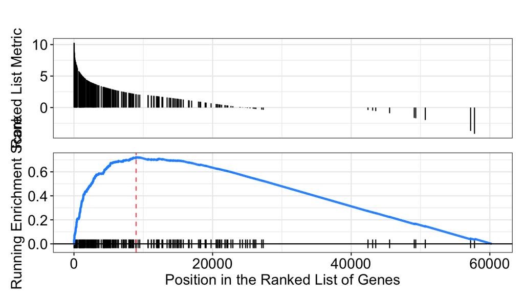

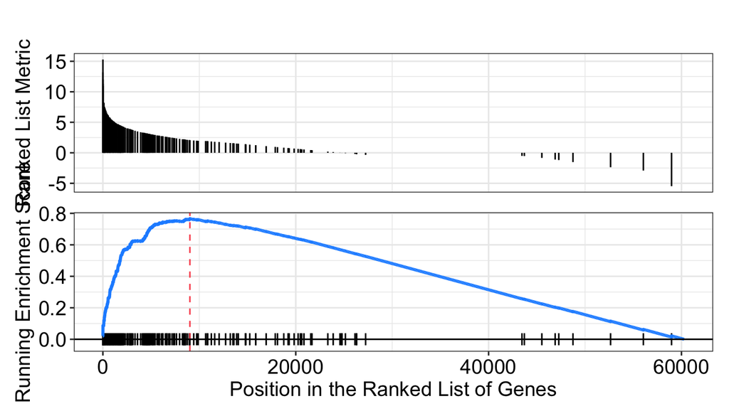

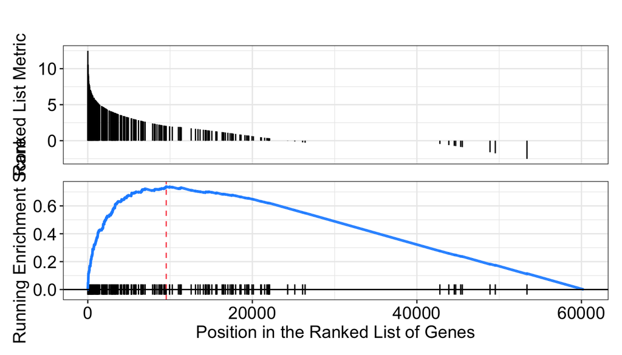

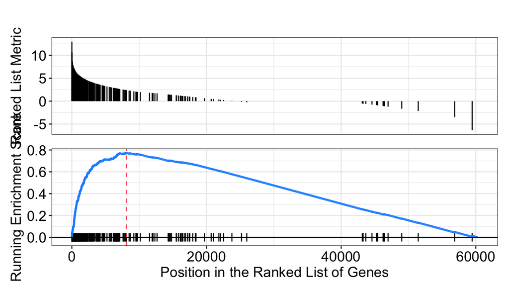

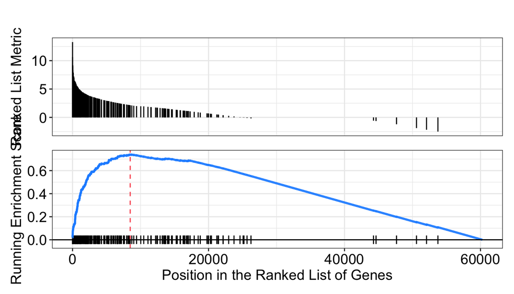

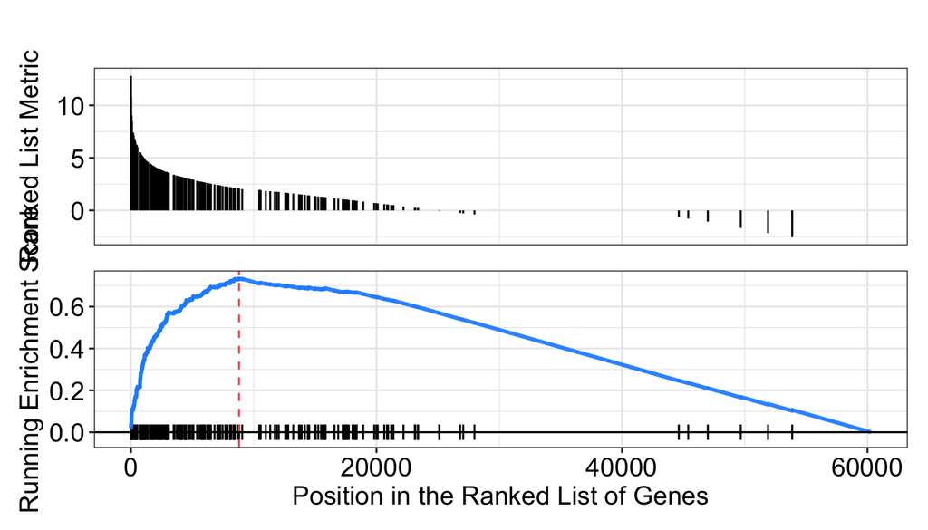

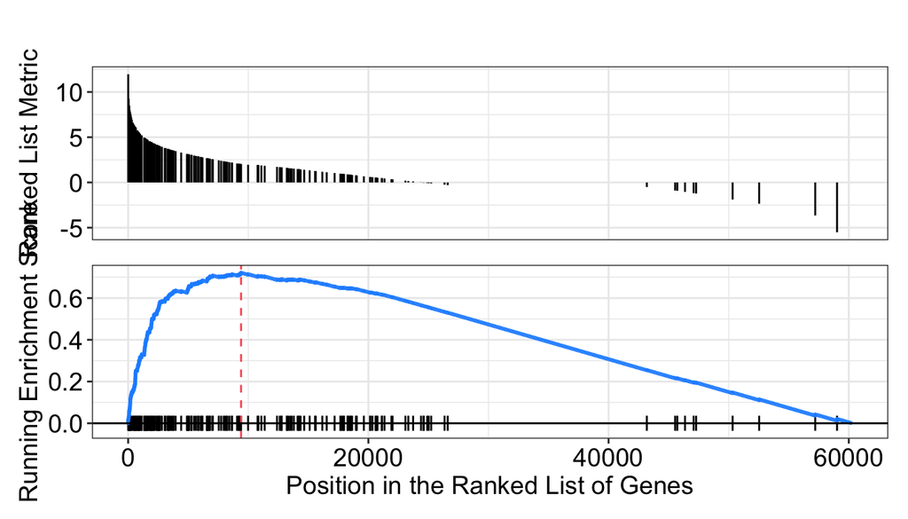

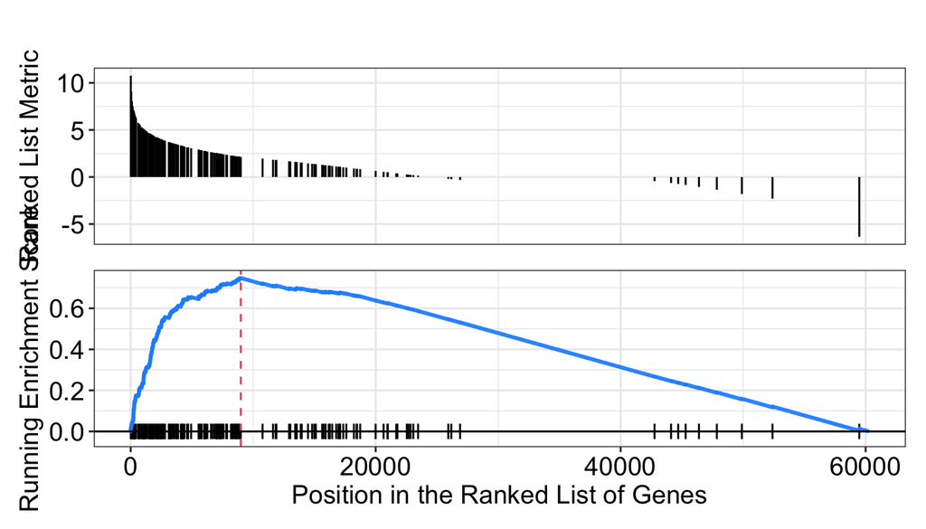

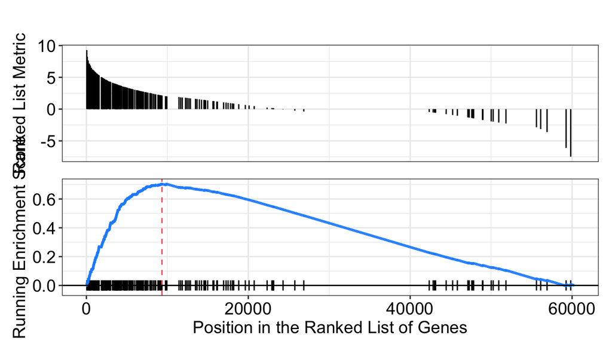

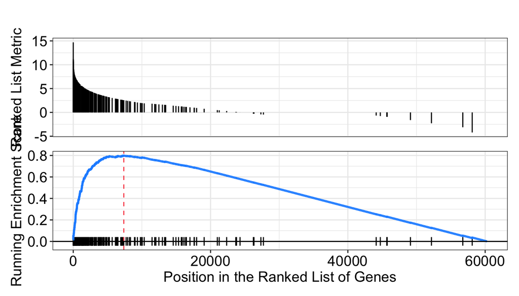

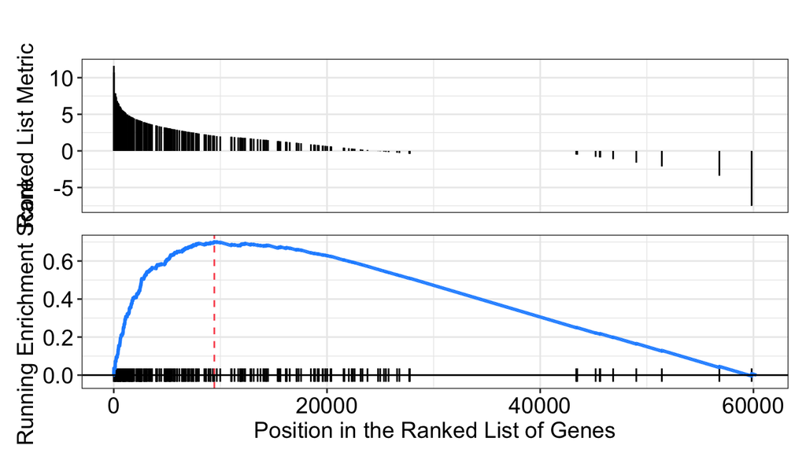

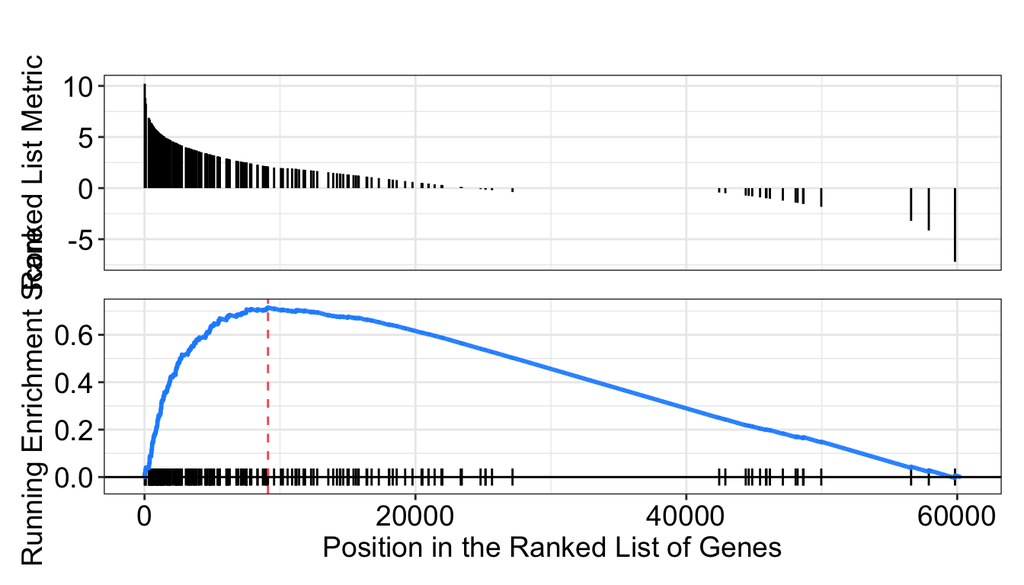

[5 more figures not shown]

```r
plot_hallmark <- "HALLMARK_EPITHELIAL_MESENCHYMAL_TRANSITION"
hallmark_gsea |>
  purrr::map(
    \(gsea_result) {
      enrichplot::gseaplot(
        gsea_result,
        geneSetID = plot_hallmark,
        color.line = "dodgerblue"
      )
  })
```

Indeed, these all look like reasonable plots for the conclusion of positive enrichment, but given that most pathways are coming out with this kind of significance, it’s not clear how meaningful the results are.